# Métodos iterativos

#### Ejercicio 3.

3x1−0.5x2+0.6x3 = 5.24 0.3x1−4x2−x3 = −0.387 −0.7x1+2x2+7x3 = 14.803

```r
A <- matrix(c(3, -0.5,0.6,0.3,-4,-1,-0.7, 2, 7), nrow = 3, byrow = TRUE)
b <- c(5.24, -0.387, 14.803)
```

```r
x <- rep(0, 3)
cat("x^(0) =", paste(sprintf("%.8f", x), collapse=", "), "\n")
```

```
## x^(0) = 0.00000000, 0.00000000, 0.00000000
```

```r
# ---- Iteración 1 ----
cat("\n---- Iteración 1 ----\n")
```

```
##
## ---- Iteración 1 ----
```

```r
x_old <- x
x[1] <- (b[1] + 0.5*x_old[2] - 0.6*x_old[3]) / 3
cat(sprintf("x1^(1) = (5.24 + 0.5*%.8f - 0.6*%.8f)/3 = %.8f\n", x_old[2], x_old[3], x[1]))
```

```
## x1^(1) = (5.24 + 0.5*0.00000000 - 0.6*0.00000000)/3 = 1.74666667
```

```r
x[2] <- (b[2] - 0.3*x[1] + 1*x_old[3]) / (-4)
cat(sprintf("x2^(1) = (-0.387 - 0.3*%.8f + 1*%.8f)/-4 = %.8f\n", x[1], x_old[3], x[2]))
```

```
## x2^(1) = (-0.387 - 0.3*1.74666667 + 1*0.00000000)/-4 = 0.22775000
```

```r
x[3] <- (b[3] + 0.7*x[1] - 2*x[2]) / 7
cat(sprintf("x3^(1) = (14.803 + 0.7*%.8f - 2*%.8f)/7 = %.8f\n", x[1], x[2], x[3]))
```

```
## x3^(1) = (14.803 + 0.7*1.74666667 - 2*0.22775000)/7 = 2.22430952
```

```r
# ---- Iteración 2 ----
cat("\n---- Iteración 2 ----\n")
```

```
##
## ---- Iteración 2 ----
```

```r
x_old <- x
x[1] <- (b[1] + 0.5*x_old[2] - 0.6*x_old[3]) / 3
cat(sprintf("x1^(2) = (5.24 + 0.5*%.8f - 0.6*%.8f)/3 = %.8f\n", x_old[2], x_old[3], x[1]))
```

```
## x1^(2) = (5.24 + 0.5*0.22775000 - 0.6*2.22430952)/3 = 1.33976310
```

```r
x[2] <- (b[2] - 0.3*x[1] + 1*x_old[3]) / (-4)
cat(sprintf("x2^(2) = (-0.387 - 0.3*%.8f + 1*%.8f)/-4 = %.8f\n", x[1], x_old[3], x[2]))
```

```
## x2^(2) = (-0.387 - 0.3*1.33976310 + 1*2.22430952)/-4 = -0.35884515
```

```r
x[3] <- (b[3] + 0.7*x[1] - 2*x[2]) / 7
cat(sprintf("x3^(2) = (14.803 + 0.7*%.8f - 2*%.8f)/7 = %.8f\n", x[1], x[2], x[3]))
```

```
## x3^(2) = (14.803 + 0.7*1.33976310 - 2*-0.35884515)/7 = 2.35121778
```

```r
# ---- Iteración 3 ----
cat("\n---- Iteración 3 ----\n")
```

```
##
## ---- Iteración 3 ----
```

```r
x_old <- x
x[1] <- (b[1] + 0.5*x_old[2] - 0.6*x_old[3]) / 3
cat(sprintf("x1^(3) = (5.24 + 0.5*%.8f - 0.6*%.8f)/3 = %.8f\n", x_old[2], x_old[3], x[1]))
```

```
## x1^(3) = (5.24 + 0.5*-0.35884515 - 0.6*2.35121778)/3 = 1.21661559
```

```r
x[2] <- (b[2] - 0.3*x[1] + 1*x_old[3]) / (-4)
cat(sprintf("x2^(3) = (-0.387 - 0.3*%.8f + 1*%.8f)/-4 = %.8f\n", x[1], x_old[3], x[2]))
```

```
## x2^(3) = (-0.387 - 0.3*1.21661559 + 1*2.35121778)/-4 = -0.39980828
```

```r
x[3] <- (b[3] + 0.7*x[1] - 2*x[2]) / 7
cat(sprintf("x3^(3) = (14.803 + 0.7*%.8f - 2*%.8f)/7 = %.8f\n", x[1], x[2], x[3]))
```

```
## x3^(3) = (14.803 + 0.7*1.21661559 - 2*-0.39980828)/7 = 2.35060678
```

```r
# ---- Iteración 4 ----
cat("\n---- Iteración 4 ----\n")
```

```
##
## ---- Iteración 4 ----
```

```r
x_old <- x
x[1] <- (b[1] + 0.5*x_old[2] - 0.6*x_old[3]) / 3
cat(sprintf("x1^(4) = (5.24 + 0.5*%.8f - 0.6*%.8f)/3 = %.8f\n", x_old[2], x_old[3], x[1]))
```

```
## x1^(4) = (5.24 + 0.5*-0.39980828 - 0.6*2.35060678)/3 = 1.20991060
```

```r
x[2] <- (b[2] - 0.3*x[1] + 1*x_old[3]) / (-4)
cat(sprintf("x2^(4) = (-0.387 - 0.3*%.8f + 1*%.8f)/-4 = %.8f\n", x[1], x_old[3], x[2]))
```

```
## x2^(4) = (-0.387 - 0.3*1.20991060 + 1*2.35060678)/-4 = -0.40015840
```

```r
x[3] <- (b[3] + 0.7*x[1] - 2*x[2]) / 7
cat(sprintf("x3^(4) = (14.803 + 0.7*%.8f - 2*%.8f)/7 = %.8f\n", x[1], x[2], x[3]))
```

```
## x3^(4) = (14.803 + 0.7*1.20991060 - 2*-0.40015840)/7 = 2.35003632
```

```r
# ---- Iteración 5 ----
cat("\n---- Iteración 5 ----\n")
```

```
##
## ---- Iteración 5 ----
```

```r
x_old <- x
x[1] <- (b[1] + 0.5*x_old[2] - 0.6*x_old[3]) / 3
cat(sprintf("x1^(5) = (5.24 + 0.5*%.8f - 0.6*%.8f)/3 = %.8f\n", x_old[2], x_old[3], x[1]))
```

```
## x1^(5) = (5.24 + 0.5*-0.40015840 - 0.6*2.35003632)/3 = 1.20996634
```

```r
x[2] <- (b[2] - 0.3*x[1] + 1*x_old[3]) / (-4)
cat(sprintf("x2^(5) = (-0.387 - 0.3*%.8f + 1*%.8f)/-4 = %.8f\n", x[1], x_old[3], x[2]))
```

```
## x2^(5) = (-0.387 - 0.3*1.20996634 + 1*2.35003632)/-4 = -0.40001160
```

```r
x[3] <- (b[3] + 0.7*x[1] - 2*x[2]) / 7
cat(sprintf("x3^(5) = (14.803 + 0.7*%.8f - 2*%.8f)/7 = %.8f\n", x[1], x[2], x[3]))
```

```
## x3^(5) = (14.803 + 0.7*1.20996634 - 2*-0.40001160)/7 = 2.34999995
```

```r
# ---- Iteración 6 ----
cat("\n---- Iteración 6 ----\n")
```

```
##
## ---- Iteración 6 ----
```

```r
x_old <- x
x[1] <- (b[1] + 0.5*x_old[2] - 0.6*x_old[3]) / 3
cat(sprintf("x1^(6) = (5.24 + 0.5*%.8f - 0.6*%.8f)/3 = %.8f\n", x_old[2], x_old[3], x[1]))
```

```
## x1^(6) = (5.24 + 0.5*-0.40001160 - 0.6*2.34999995)/3 = 1.20999808
```

```r
x[2] <- (b[2] - 0.3*x[1] + 1*x_old[3]) / (-4)
cat(sprintf("x2^(6) = (-0.387 - 0.3*%.8f + 1*%.8f)/-4 = %.8f\n", x[1], x_old[3], x[2]))
```

```
## x2^(6) = (-0.387 - 0.3*1.20999808 + 1*2.34999995)/-4 = -0.40000013
```

```r
x[3] <- (b[3] + 0.7*x[1] - 2*x[2]) / 7
cat(sprintf("x3^(6) = (14.803 + 0.7*%.8f - 2*%.8f)/7 = %.8f\n", x[1], x[2], x[3]))
```

```
## x3^(6) = (14.803 + 0.7*1.20999808 - 2*-0.40000013)/7 = 2.34999985
```

```r
# ---- Iteración 7 ----
cat("\n---- Iteración 7 ----\n")
```

```
##
## ---- Iteración 7 ----
```

```r
x_old <- x
x[1] <- (b[1] + 0.5*x_old[2] - 0.6*x_old[3]) / 3
cat(sprintf("x1^(7) = (5.24 + 0.5*%.8f - 0.6*%.8f)/3 = %.8f\n", x_old[2], x_old[3], x[1]))
```

```
## x1^(7) = (5.24 + 0.5*-0.40000013 - 0.6*2.34999985)/3 = 1.21000001
```

```r
x[2] <- (b[2] - 0.3*x[1] + 1*x_old[3]) / (-4)
cat(sprintf("x2^(7) = (-0.387 - 0.3*%.8f + 1*%.8f)/-4 = %.8f\n", x[1], x_old[3], x[2]))
```

```
## x2^(7) = (-0.387 - 0.3*1.21000001 + 1*2.34999985)/-4 = -0.39999996
```

```r
x[3] <- (b[3] + 0.7*x[1] - 2*x[2]) / 7
cat(sprintf("x3^(7) = (14.803 + 0.7*%.8f - 2*%.8f)/7 = %.8f\n", x[1], x[2], x[3]))
```

```
## x3^(7) = (14.803 + 0.7*1.21000001 - 2*-0.39999996)/7 = 2.34999999
```

```r
# ---- Iteración 8 ----
cat("\n---- Iteración 8 ----\n")
```

```
##
## ---- Iteración 8 ----
```

```r
x_old <- x
x[1] <- (b[1] + 0.5*x_old[2] - 0.6*x_old[3]) / 3
cat(sprintf("x1^(8) = (5.24 + 0.5*%.8f - 0.6*%.8f)/3 = %.8f\n", x_old[2], x_old[3], x[1]))
```

```
## x1^(8) = (5.24 + 0.5*-0.39999996 - 0.6*2.34999999)/3 = 1.21000001
```

```r
x[2] <- (b[2] - 0.3*x[1] + 1*x_old[3]) / (-4)
cat(sprintf("x2^(8) = (-0.387 - 0.3*%.8f + 1*%.8f)/-4 = %.8f\n", x[1], x_old[3], x[2]))
```

```
## x2^(8) = (-0.387 - 0.3*1.21000001 + 1*2.34999999)/-4 = -0.40000000
```

```r
x[3] <- (b[3] + 0.7*x[1] - 2*x[2]) / 7
cat(sprintf("x3^(8) = (14.803 + 0.7*%.8f - 2*%.8f)/7 = %.8f\n", x[1], x[2], x[3]))
```

```
## x3^(8) = (14.803 + 0.7*1.21000001 - 2*-0.40000000)/7 = 2.35000000
```

```r
# Solución exacta
x_exacta <- solve(A, b)
cat("\nSolución exacta (solve):", paste(sprintf("%.8f", x_exacta), collapse=", "), "\n")
```

```
##
## Solución exacta (solve): 1.21000000, -0.40000000, 2.35000000
```

#### Ejercicio 4.

5x1−0.2x2+x3 = 1.5 0.1x1+3x2−0.5x3 = −2.7 −0.3x1+x2−7x3 = 9.5

```r
A <- matrix(c(5,-0.2,1,0.1,3,-0.5,-0.3,1,-7), nrow = 3, byrow = TRUE)

b <- c(1.5,-2.7,9.5)
```

```r
x <- rep(0, 3)
cat("x^(0) =", paste(sprintf("%.8f", x), collapse=", "), "\n")
```

```
## x^(0) = 0.00000000, 0.00000000, 0.00000000
```

```r
# ---- Iteración 1 ----
x1 <- (1.5 + 0.2*0 - 0)/5
x2 <- (-2.7 - 0.1*x1 + 0.5*0)/3
x3 <- (-9.5 + 0.3*x1 - x2)/-7
cat("\nIteración 1\n")
```

```
##
## Iteración 1
```

```r
cat(sprintf("x1^(1) = %.8f\n", x1))
```

```
## x1^(1) = 0.30000000
```

```r
cat(sprintf("x2^(1) = %.8f\n", x2))
```

```
## x2^(1) = -0.91000000
```

```r
cat(sprintf("x3^(1) = %.8f\n", x3))
```

```
## x3^(1) = 1.21428571
```

```r
cat(sprintf("x^(1) = (%.8f, %.8f, %.8f)\n", x1, x2, x3))
```

```
## x^(1) = (0.30000000, -0.91000000, 1.21428571)
```

```r
# ---- Iteración 2 ----
x1 <- (1.5 + 0.2*x2 - x3)/5
x2 <- (-2.7 - 0.1*x1 + 0.5*x3)/3
x3 <- (-9.5 + 0.3*x1 - x2)/-7
cat("\nIteración 2\n")
```

```
##
## Iteración 2
```

```r
cat(sprintf("x1^(2) = %.8f\n", x1))
```

```
## x1^(2) = 0.02074286
```

```r
cat(sprintf("x2^(2) = %.8f\n", x2))
```

```
## x2^(2) = -0.69831048
```

```r
cat(sprintf("x3^(2) = %.8f\n", x3))
```

```
## x3^(2) = 1.25649524
```

```r
cat(sprintf("x^(2) = (%.8f, %.8f, %.8f)\n", x1, x2, x3))
```

```
## x^(2) = (0.02074286, -0.69831048, 1.25649524)
```

```r
# ---- Iteración 3 ----
x1 <- (1.5 + 0.2*x2 - x3)/5
x2 <- (-2.7 - 0.1*x1 + 0.5*x3)/3
x3 <- (-9.5 + 0.3*x1 - x2)/-7
cat("\nIteración 3\n")
```

```
##
## Iteración 3
```

```r
cat(sprintf("x1^(3) = %.8f\n", x1))
```

```
## x1^(3) = 0.02076853
```

```r
cat(sprintf("x2^(3) = %.8f\n", x2))
```

```
## x2^(3) = -0.69127641
```

```r
cat(sprintf("x3^(3) = %.8f\n", x3))
```

```
## x3^(3) = 1.25749900
```

```r
cat(sprintf("x^(3) = (%.8f, %.8f, %.8f)\n", x1, x2, x3))
```

```
## x^(3) = (0.02076853, -0.69127641, 1.25749900)
```

```r
# ---- Iteración 4 ----
x1 <- (1.5 + 0.2*x2 - x3)/5
x2 <- (-2.7 - 0.1*x1 + 0.5*x3)/3
x3 <- (-9.5 + 0.3*x1 - x2)/-7
cat("\nIteración 4\n")
```

```
##
## Iteración 4
```

```r
cat(sprintf("x1^(4) = %.8f\n", x1))
```

```
## x1^(4) = 0.02084914
```

```r
cat(sprintf("x2^(4) = %.8f\n", x2))
```

```
## x2^(4) = -0.69111180
```

```r
cat(sprintf("x3^(4) = %.8f\n", x3))
```

```
## x3^(4) = 1.25751906
```

```r
cat(sprintf("x^(4) = (%.8f, %.8f, %.8f)\n", x1, x2, x3))
```

```
## x^(4) = (0.02084914, -0.69111180, 1.25751906)
```

```r
# ---- Iteración 5 ----
x1 <- (1.5 + 0.2*x2 - x3)/5
x2 <- (-2.7 - 0.1*x1 + 0.5*x3)/3
x3 <- (-9.5 + 0.3*x1 - x2)/-7
cat("\nIteración 5\n")
```

```
##
## Iteración 5
```

```r
cat(sprintf("x1^(5) = %.8f\n", x1))
```

```
## x1^(5) = 0.02085171
```

```r
cat(sprintf("x2^(5) = %.8f\n", x2))
```

```
## x2^(5) = -0.69110855
```

```r
cat(sprintf("x3^(5) = %.8f\n", x3))
```

```
## x3^(5) = 1.25751942
```

```r
cat(sprintf("x^(5) = (%.8f, %.8f, %.8f)\n", x1, x2, x3))
```

```
## x^(5) = (0.02085171, -0.69110855, 1.25751942)
```

```r
# ---- Iteración 6 ----
x1 <- (1.5 + 0.2*x2 - x3)/5
x2 <- (-2.7 - 0.1*x1 + 0.5*x3)/3
x3 <- (-9.5 + 0.3*x1 - x2)/-7
cat("\nIteración 6\n")
```

```
##
## Iteración 6
```

```r
cat(sprintf("x1^(6) = %.8f\n", x1))
```

```
## x1^(6) = 0.02085177
```

```r
cat(sprintf("x2^(6) = %.8f\n", x2))
```

```
## x2^(6) = -0.69110849
```

```r
cat(sprintf("x3^(6) = %.8f\n", x3))
```

```
## x3^(6) = 1.25751943
```

```r
cat(sprintf("x^(6) = (%.8f, %.8f, %.8f)\n", x1, x2, x3))
```

```
## x^(6) = (0.02085177, -0.69110849, 1.25751943)
```

#### Ejercicio 6.

```r
A <- matrix(c(0, 2.11, 30.75,0.64, 1.21, 2.05,3.21, 1.53, 1.04), nrow=3, byrow=TRUE)
b <- c(-26.531, 1.01, 5.23)
```

```r
x <- rep(0, 3)   # x^(0) = [0,0,0]
cat("x^(0) =", paste(sprintf("%.6f", x), collapse=", "), "\n\n")
```

```
## x^(0) = 0.000000, 0.000000, 0.000000
```

```r
# --- Iteración 1 ---
x_old <- x
x[2] <- (-26.531 - A[1,3]*x_old[3]) / 2.11
x[3] <- (5.23 - 3.21*x_old[1] - 1.53*x[2]) / 1.04
x[1] <- (1.01 - 1.21*x[2] - 2.05*x[3]) / 0.64
cat("Iteración 1: x1 =", sprintf("%.6f", x[1]),
    "x2 =", sprintf("%.6f", x[2]),
    "x3 =", sprintf("%.6f", x[3]), "\n\n")
```

```
## Iteración 1: x1 = -50.009322 x2 = -12.573934 x3 = 23.527037
```

```r
# --- Iteración 2 ---
x_old <- x
x[2] <- (-26.531 - A[1,3]*x_old[3]) / 2.11
x[3] <- (5.23 - 3.21*x_old[1] - 1.53*x[2]) / 1.04
x[1] <- (1.01 - 1.21*x[2] - 2.05*x[3]) / 0.64
cat("Iteración 2: x1 =", sprintf("%.6f", x[1]),
    "x2 =", sprintf("%.6f", x[2]),
    "x3 =", sprintf("%.6f", x[3]), "\n\n")
```

```
## Iteración 2: x1 = -1511.894994 x2 = -355.444260 x3 = 682.297732
```

```r
x_old <- x
x[2] <- (-26.531 - A[1,3]*x_old[3]) / 2.11
x[3] <- (5.23 - 3.21*x_old[1] - 1.53*x[2]) / 1.04
x[1] <- (1.01 - 1.21*x[2] - 2.05*x[3]) / 0.64
cat("Iteración 3: x1 =", sprintf("%.6f", x[1]),
    "x2 =", sprintf("%.6f", x[2]),
    "x3 =", sprintf("%.6f", x[3]), "\n\n")
```

```
## Iteración 3: x1 = -43054.511838 x2 = -9956.012444 x3 = 19318.376894
```

```r
# --- Iteración 4 ---
x_old <- x
x[2] <- (-26.531 - A[1,3]*x_old[3]) / 2.11
x[3] <- (5.23 - 3.21*x_old[1] - 1.53*x[2]) / 1.04
x[1] <- (1.01 - 1.21*x[2] - 2.05*x[3]) / 0.64
cat("Iteración 4: x1 =", sprintf("%.6f", x[1]),
    "x2 =", sprintf("%.6f", x[2]),
    "x3 =", sprintf("%.6f", x[3]), "\n\n")
```

```
## Iteración 4: x1 = -1220110.408838 x2 = -281548.161373 x3 = 547095.096057
```

```r
# --- Iteración 5 ---
x_old <- x
x[2] <- (-26.531 - A[1,3]*x_old[3]) / 2.11
x[3] <- (5.23 - 3.21*x_old[1] - 1.53*x[2]) / 1.04
x[1] <- (1.01 - 1.21*x[2] - 2.05*x[3]) / 0.64
cat("Iteración 5: x1 =", sprintf("%.6f", x[1]),
    "x2 =", sprintf("%.6f", x[2]),
    "x3 =", sprintf("%.6f", x[3]), "\n\n")
```

```
## Iteración 5: x1 = -34560080.358441 x2 = -7973080.916947 x3 = 15495551.389711
```

```r
cat(" Se observa crecimiento excesivo: el método está divergiendo.\n")
```

```
##  Se observa crecimiento excesivo: el método está divergiendo.
```

#### Ejercicio 9.

3x−0.1y−0.2z = 7.85 0.1x+7y−0.3z = −19.3 0.3x1−0.2x2+10x3=71.4

```r
A <- matrix(c(3, -0.1, -0.2,0.1, 7, -0.3,0.3, -0.2, 10), nrow=3, byrow=TRUE)
b <- c(7.85, -19.3, 71.4)
```

```r
x <- rep(0,3)
cat("x^(0) =", paste(sprintf("%.8f", x), collapse=", "), "\n")
```

```
## x^(0) = 0.00000000, 0.00000000, 0.00000000
```

```r
# ---- Iteración 1 ----
x_old <- x
cat("\nIteración 1\n")
```

```
##
## Iteración 1
```

```r
x[1] <- (b[1] + 0.1*x_old[2] + 0.2*x_old[3])/A[1,1]
cat(sprintf("x1^(1) = (7.85 + 0.1*0 + 0.2*0)/3 = %.8f\n", x[1]))
```

```
## x1^(1) = (7.85 + 0.1*0 + 0.2*0)/3 = 2.61666667
```

```r
x[2] <- (-19.3 - 0.1*x[1] + 0.3*x_old[3])/A[2,2]
cat(sprintf("x2^(1) = (-19.3 - 0.1*%.8f + 0.3*0)/7 = %.8f\n", x[1], x[2]))
```

```
## x2^(1) = (-19.3 - 0.1*2.61666667 + 0.3*0)/7 = -2.79452381
```

```r
x[3] <- (b[3] - 0.3*x[1] + 0.2*x[2])/A[3,3]
cat(sprintf("x3^(1) = (71.4 - 0.3*%.8f + 0.2*%.8f)/10 = %.8f\n", x[1], x[2], x[3]))
```

```
## x3^(1) = (71.4 - 0.3*2.61666667 + 0.2*-2.79452381)/10 = 7.00560952
```

```r
cat(sprintf("x^(1) = (%.8f, %.8f, %.8f)\n", x[1], x[2], x[3]))
```

```
## x^(1) = (2.61666667, -2.79452381, 7.00560952)
```

```r
# ---- Iteración 2 ----
x_old <- x
cat("\nIteración 2\n")
```

```
##
## Iteración 2
```

```r
x[1] <- (b[1] + 0.1*x_old[2] + 0.2*x_old[3])/A[1,1]
cat(sprintf("x1^(2) = (7.85 + 0.1*%.8f + 0.2*%.8f)/3 = %.8f\n", x_old[2], x_old[3], x[1]))
```

```
## x1^(2) = (7.85 + 0.1*-2.79452381 + 0.2*7.00560952)/3 = 2.99055651
```

```r
x[2] <- (-19.3 - 0.1*x[1] + 0.3*x_old[3])/A[2,2]
cat(sprintf("x2^(2) = (-19.3 - 0.1*%.8f + 0.3*%.8f)/7 = %.8f\n", x[1], x_old[3], x[2]))
```

```
## x2^(2) = (-19.3 - 0.1*2.99055651 + 0.3*7.00560952)/7 = -2.49962468
```

```r
x[3] <- (b[3] - 0.3*x[1] + 0.2*x[2])/A[3,3]
cat(sprintf("x3^(2) = (71.4 - 0.3*%.8f + 0.2*%.8f)/10 = %.8f\n", x[1], x[2], x[3]))
```

```
## x3^(2) = (71.4 - 0.3*2.99055651 + 0.2*-2.49962468)/10 = 7.00029081
```

```r
cat(sprintf("x^(2) = (%.8f, %.8f, %.8f)\n", x[1], x[2], x[3]))
```

```
## x^(2) = (2.99055651, -2.49962468, 7.00029081)
```

```r
# ---- Iteración 3 ----
x_old <- x
cat("\nIteración 3\n")
```

```
##
## Iteración 3
```

```r
x[1] <- (b[1] + 0.1*x_old[2] + 0.2*x_old[3])/A[1,1]
cat(sprintf("x1^(3) = (7.85 + 0.1*%.8f + 0.2*%.8f)/3 = %.8f\n", x_old[2], x_old[3], x[1]))
```

```
## x1^(3) = (7.85 + 0.1*-2.49962468 + 0.2*7.00029081)/3 = 3.00003190
```

```r
x[2] <- (-19.3 - 0.1*x[1] + 0.3*x_old[3])/A[2,2]
cat(sprintf("x2^(3) = (-19.3 - 0.1*%.8f + 0.3*%.8f)/7 = %.8f\n", x[1], x_old[3], x[2]))
```

```
## x2^(3) = (-19.3 - 0.1*3.00003190 + 0.3*7.00029081)/7 = -2.49998799
```

```r
x[3] <- (b[3] - 0.3*x[1] + 0.2*x[2])/A[3,3]
cat(sprintf("x3^(3) = (71.4 - 0.3*%.8f + 0.2*%.8f)/10 = %.8f\n", x[1], x[2], x[3]))
```

```
## x3^(3) = (71.4 - 0.3*3.00003190 + 0.2*-2.49998799)/10 = 6.99999928
```

```r
cat(sprintf("x^(3) = (%.8f, %.8f, %.8f)\n", x[1], x[2], x[3]))
```

```
## x^(3) = (3.00003190, -2.49998799, 6.99999928)
```

```r
# ---- Iteración 4 ----
x_old <- x
cat("\nIteración 4\n")
```

```
##
## Iteración 4
```

```r
x[1] <- (b[1] + 0.1*x_old[2] + 0.2*x_old[3])/A[1,1]
cat(sprintf("x1^(4) = (7.85 + 0.1*%.8f + 0.2*%.8f)/3 = %.8f\n", x_old[2], x_old[3], x[1]))
```

```
## x1^(4) = (7.85 + 0.1*-2.49998799 + 0.2*6.99999928)/3 = 3.00000035
```

```r
x[2] <- (-19.3 - 0.1*x[1] + 0.3*x_old[3])/A[2,2]
cat(sprintf("x2^(4) = (-19.3 - 0.1*%.8f + 0.3*%.8f)/7 = %.8f\n", x[1], x_old[3], x[2]))
```

```
## x2^(4) = (-19.3 - 0.1*3.00000035 + 0.3*6.99999928)/7 = -2.50000004
```

```r
x[3] <- (b[3] - 0.3*x[1] + 0.2*x[2])/A[3,3]
cat(sprintf("x3^(4) = (71.4 - 0.3*%.8f + 0.2*%.8f)/10 = %.8f\n", x[1], x[2], x[3]))
```

```
## x3^(4) = (71.4 - 0.3*3.00000035 + 0.2*-2.50000004)/10 = 6.99999999
```

```r
cat(sprintf("x^(4) = (%.8f, %.8f, %.8f)\n", x[1], x[2], x[3]))
```

```
## x^(4) = (3.00000035, -2.50000004, 6.99999999)
```

```r
# ---- Iteración 5 ----
x_old <- x
cat("\nIteración 5\n")
```

```
##
## Iteración 5
```

```r
x[1] <- (b[1] + 0.1*x_old[2] + 0.2*x_old[3])/A[1,1]
cat(sprintf("x1^(5) = (7.85 + 0.1*%.8f + 0.2*%.8f)/3 = %.8f\n", x_old[2], x_old[3], x[1]))
```

```
## x1^(5) = (7.85 + 0.1*-2.50000004 + 0.2*6.99999999)/3 = 3.00000000
```

```r
x[2] <- (-19.3 - 0.1*x[1] + 0.3*x_old[3])/A[2,2]
cat(sprintf("x2^(5) = (-19.3 - 0.1*%.8f + 0.3*%.8f)/7 = %.8f\n", x[1], x_old[3], x[2]))
```

```
## x2^(5) = (-19.3 - 0.1*3.00000000 + 0.3*6.99999999)/7 = -2.50000000
```

```r
x[3] <- (b[3] - 0.3*x[1] + 0.2*x[2])/A[3,3]
cat(sprintf("x3^(5) = (71.4 - 0.3*%.8f + 0.2*%.8f)/10 = %.8f\n", x[1], x[2], x[3]))
```

```
## x3^(5) = (71.4 - 0.3*3.00000000 + 0.2*-2.50000000)/10 = 7.00000000
```

```r
cat(sprintf("x^(5) = (%.8f, %.8f, %.8f)\n", x[1], x[2], x[3]))
```

```
## x^(5) = (3.00000000, -2.50000000, 7.00000000)
```

```r
# ---- Solución final aproximada ----
cat("\nSolución aproximada después de 5 iteraciones:\n")
```

```
##
## Solución aproximada después de 5 iteraciones:
```

```r
cat(sprintf("x ≈ %.8f, y ≈ %.8f, z ≈ %.8f\n", x[1], x[2], x[3]))
```

```
## x ≈ 3.00000000, y ≈ -2.50000000, z ≈ 7.00000000
```

#### Ejercicio 10.

17x1−2x2−3x3=500 −5x1+21x2−2x3 = 200 −5x1−5x2+22x3 = 30

```r
A <- matrix(c(17,-2,-3,-5, 21,-2,-5,-5,22), nrow = 3, byrow = TRUE)
b <- c(500, 200, 30)
```

```r
x <- rep(0,3)
cat("x^(0) =", paste(sprintf("%.8f", x), collapse=", "), "\n")
```

```
## x^(0) = 0.00000000, 0.00000000, 0.00000000
```

```r
# ---- Iteración 1 ----
x_old <- x
cat("\nIteración 1\n")
```

```
##
## Iteración 1
```

```r
x[1] <- (b[1] + 2*x_old[2] + 3*x_old[3])/17
cat(sprintf("x1^(1) = (500 + 2*0 + 3*0)/17 = %.8f\n", x[1]))
```

```
## x1^(1) = (500 + 2*0 + 3*0)/17 = 29.41176471
```

```r
x[2] <- (b[2] + 5*x[1] + 2*x_old[3])/21
cat(sprintf("x2^(1) = (200 + 5*%.8f + 2*0)/21 = %.8f\n", x[1], x[2]))
```

```
## x2^(1) = (200 + 5*29.41176471 + 2*0)/21 = 16.52661064
```

```r
x[3] <- (b[3] + 5*x[1] + 5*x[2])/22
cat(sprintf("x3^(1) = (30 + 5*%.8f + 5*%.8f)/22 = %.8f\n", x[1], x[2], x[3]))
```

```
## x3^(1) = (30 + 5*29.41176471 + 5*16.52661064)/22 = 11.80417622
```

```r
# ---- Iteración 2 ----
x_old <- x
cat("\nIteración 2\n")
```

```
##
## Iteración 2
```

```r
x[1] <- (b[1] + 2*x_old[2] + 3*x_old[3])/17
x[2] <- (b[2] + 5*x[1] + 2*x_old[3])/21
x[3] <- (b[3] + 5*x[1] + 5*x[2])/22
cat(sprintf("x^(2) = %.8f, %.8f, %.8f\n", x[1], x[2], x[3]))
```

```
## x^(2) = 33.43916176, 18.60972196, 13.19292812
```

```r
# ---- Iteración 3 ----
x_old <- x
cat("\nIteración 3\n")
```

```
##
## Iteración 3
```

```r
x[1] <- (b[1] + 2*x_old[2] + 3*x_old[3])/17
x[2] <- (b[2] + 5*x[1] + 2*x_old[3])/21
x[3] <- (b[3] + 5*x[1] + 5*x[2])/22
cat(sprintf("x^(3) = %.8f, %.8f, %.8f\n", x[1], x[2], x[3]))
```

```
## x^(3) = 33.92930755, 18.85868543, 13.36090749
```

```r
# ---- Iteración 4 ----
x_old <- x
cat("\nIteración 4\n")
```

```
##
## Iteración 4
```

```r
x[1] <- (b[1] + 2*x_old[2] + 3*x_old[3])/17
x[2] <- (b[2] + 5*x[1] + 2*x_old[3])/21
x[3] <- (b[3] + 5*x[1] + 5*x[2])/22
cat(sprintf("x^(4) = %.8f, %.8f, %.8f\n", x[1], x[2], x[3]))
```

```
## x^(4) = 33.98824078, 18.88871519, 13.38112636
```

```r
# ---- Iteración 6 ----
x_old <- x
cat("\nIteración 5\n")
```

```
##
## Iteración 5
```

```r
x[1] <- (b[1] + 2*x_old[2] + 3*x_old[3])/17
x[2] <- (b[2] + 5*x[1] + 2*x_old[3])/21
x[3] <- (b[3] + 5*x[1] + 5*x[2])/22
cat(sprintf("x^(5) = %.8f, %.8f, %.8f\n", x[1], x[2], x[3]))
```

```
## x^(5) = 33.99534173, 18.89233149, 13.38356210
```

```r
# ---- Iteraciones de 6 a 10 ----
for(k in 6:10){
  x_old <- x
  x[1] <- (b[1] + 2*x_old[2] + 3*x_old[3])/17
  x[2] <- (b[2] + 5*x[1] + 2*x_old[3])/21
  x[3] <- (b[3] + 5*x[1] + 5*x[2])/22
  dx_inf <- max(abs(x - x_old))
  cat(sprintf("\nIteración %d: x = %.8f, %.8f, %.8f | ||dx||_inf = %.8e", k, x[1], x[2], x[3], dx_inf))
  if(dx_inf < 1e-6) cat(" <- Convergencia alcanzada")
  cat("\n")
}
```

```
##
## Iteración 6: x = 33.99619702, 18.89276711, 13.38385548 | ||dx||_inf = 8.55284416e-04
##
## Iteración 7: x = 33.99630004, 18.89281958, 13.38389082 | ||dx||_inf = 1.03022765e-04
##
## Iteración 8: x = 33.99631245, 18.89282590, 13.38389508 | ||dx||_inf = 1.24094022e-05
##
## Iteración 9: x = 33.99631394, 18.89282666, 13.38389559 | ||dx||_inf = 1.49475287e-06
##
## Iteración 10: x = 33.99631412, 18.89282675, 13.38389565 | ||dx||_inf = 1.80047785e-07 <- Convergencia alcanzada
```

```r
# Solución exacta opcional
x_exacta <- solve(A,b)
cat("\nSolución exacta: ", paste(sprintf("%.8f", x_exacta), collapse=", "), "\n")
```

```
##
## Solución exacta:  33.99631415, 18.89282676, 13.38389566
```

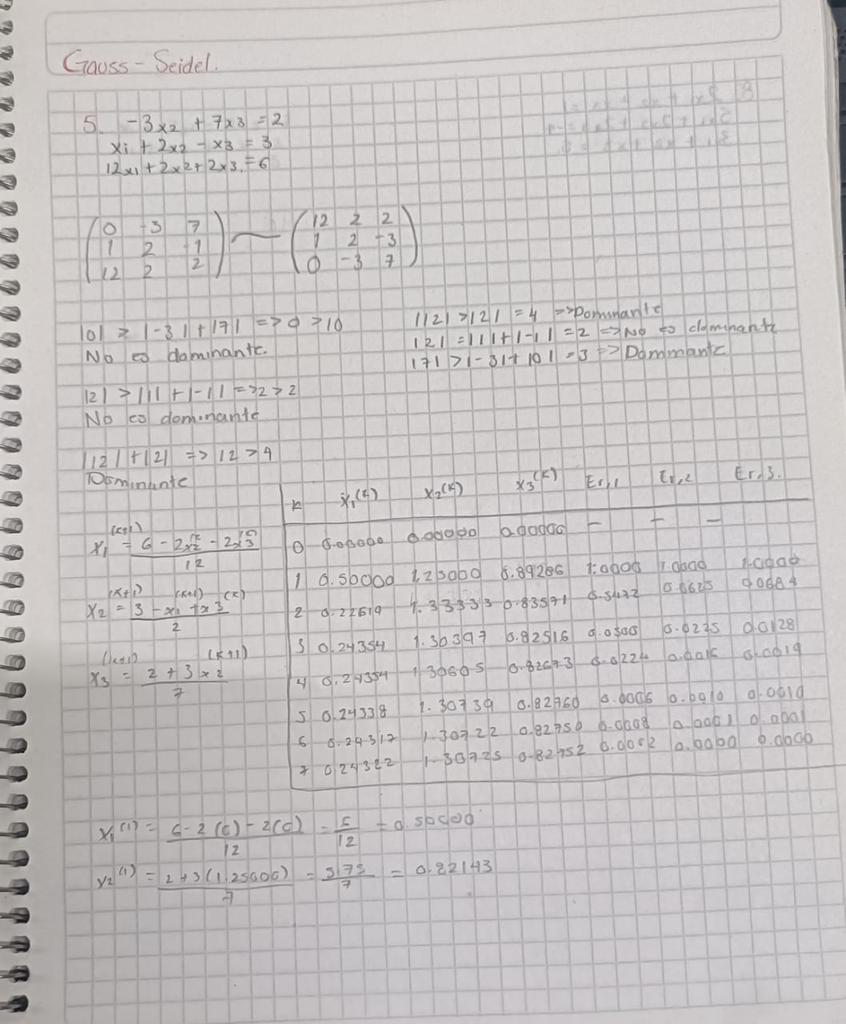

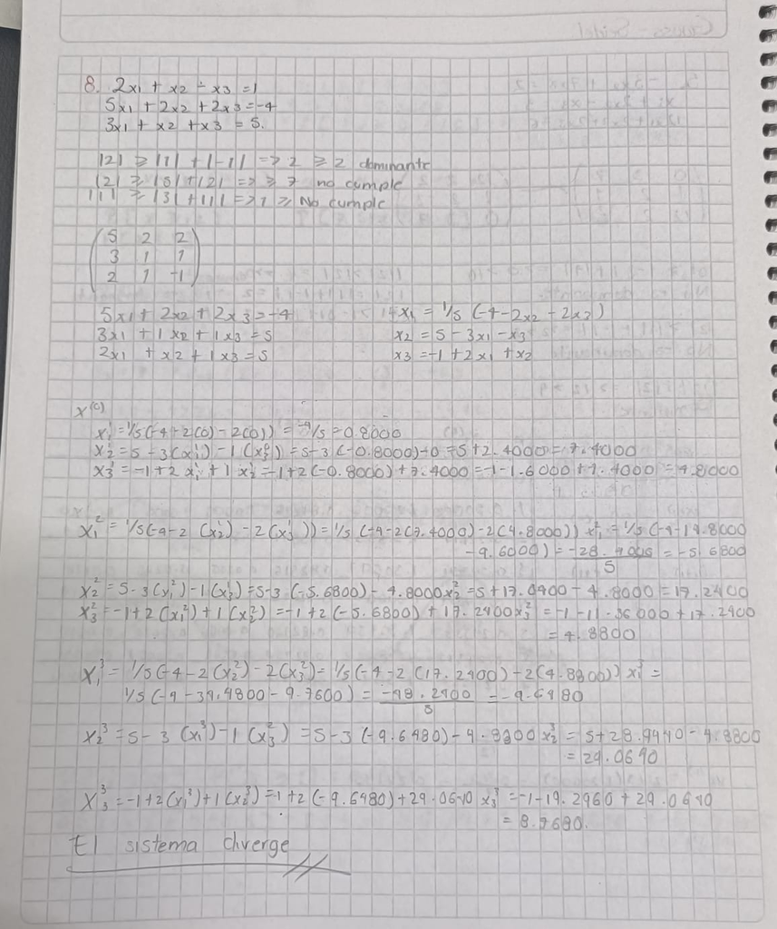